# P8105 Homework 2: Data Wrangling

Catherine Lucey (UNI: cml2270)

10/10/21

## Setup

Only done once, the setup code loads the necessary libraries and double checks that the working directory is correct.

```r
library(tidyverse)
library(readxl)
library(lubridate)
getwd()
```

```
## [1] "/Users/catherinelucey/Documents/p8105_directory/p8105_hw2_cml2270"
```

# Problem 1: Mr. Trash Wheel

## Importing and Cleaning the Mr. Trash Wheel Dataset

```r
mrtrash_df = read_xlsx("data/Trash-Wheel-Collection-Totals-8-6-19.xlsx",
           sheet = "Mr. Trash Wheel",
           range = "A2:N408",
           col_names = TRUE
           ) %>%
  janitor::clean_names() %>%
  drop_na(dumpster) %>%
  mutate(sports_balls = round(sports_balls, 0))
```

## Importing and Cleaning Precipitaiotn Data for 2018 and 2019

```r
rain_2018 = read_xlsx("data/Trash-Wheel-Collection-Totals-8-6-19.xlsx",
          sheet = "2018 Precipitation",
          range = "A2:B14",
          col_names = TRUE
          ) %>%
  janitor::clean_names() %>%
  mutate(year = 2018) %>%
  mutate(month = month.name[as.numeric(month)]) %>%
  rename(total_precip = total)

rain_2019 = read_xlsx("data/Trash-Wheel-Collection-Totals-8-6-19.xlsx",
          sheet = "2019 Precipitation",
          range = "A2:B14",
          col_names = TRUE
          ) %>%
  janitor::clean_names() %>%
  drop_na() %>%
  mutate(year = 2019) %>%
  mutate(month = month.name[as.numeric(month)]) %>%
  rename(total_precip = total)

annualrain_df = bind_rows(rain_2018, rain_2019)
```

## Describing Mr. Trash Wheel and Precipitation Data

The Mr. Trash Wheel dataset provides information on how much trash the Mr. Trash Wheel trash collector picked up from 2014-05-16 to 2019-06-17 in the Baltimore Harbor. The Mr. Trash Wheel dataset gives observations for dumpster, month, year, date, weight_tons, volume_cubic_yards, plastic_bottles, polystyrene, cigarette_butts, glass_bottles, grocery_bags, chip_bags, sports_balls, homes_powered. In this way, trash collection data are given in total weight (tons) and total volume (cubic yards), as well as weight collected per trash type. These data are presented alongside monthly total inches of rainfall data, which is important because trash is more likely to overflow into the Baltimore harbor after heavy rain. Precipitation data are provided for all 12 months in 2018, in which the average total monthly rainfall was 5.8608333 inches, and 6 months in 2019, in which the average total monthly rainfall was 2.7783333 inches. The cumulative total rainfall in 2019 was 16.67, and that in 2018 was 70.33.

On Mr. Trash Wheel’s biggest trash pickup day, he collected 5.62 tons of trash. On Mr. Trash Wheel’s least productive day, he only collected 0.96 tons of trash. The median tons of sports balls Mr. Trash Wheel collected in 2019 was 8. In collecting all this trash, Mr. Trash Wheel is not only cleaning up the harbor, but also using that waste to generate electricity! On Mr. Trash Wheel’s best day, he powered 93.6666667 houses.

# Problem 2: FiveThirtyEight

```r
pols_df = read_csv("data/fivethirtyeight_datasets/pols-month.csv") %>%
  separate(mon, into = c("year", "month", "day")) %>%
  mutate(month = month.name[as.numeric(month)]) %>%
  mutate(president =
          ifelse(prez_dem == 1, "dem","gop")) %>%
  select(-prez_dem, -prez_gop, -day) %>%
  mutate(year = as.numeric(year))
snp_df = read_csv("data/fivethirtyeight_datasets/snp.csv") %>%
  mutate(date = mdy(date)) %>%
  separate(date, into = c("year","month", "day")) %>%
  mutate(year = as.numeric(year)) %>%
  mutate(year = ifelse(68 > year %% 100 & 16 > year %% 100, 2000 + year %% 100, 1900 + year %% 100)) %>%
  mutate(month = month.name[as.numeric(month)]) %>%
  select(-day) %>%
  relocate(year)
unemploy_df = read_csv("data/fivethirtyeight_datasets/unemployment.csv") %>%
  janitor::clean_names() %>%
  pivot_longer(
    jan:dec,
    names_to = "month",
    values_to = "unemployment_rate") %>%
  mutate(month = recode(month, jan = "January", feb = "February", mar = "March", apr = "April", may = "May", jun = "June", jul = "July", aug = "August", sep = "September", oct = "October", nov = "November", dec = "December" ))
unemp_pols_snp_join = inner_join(snp_df, pols_df, by = c("year", "month")) %>%
  inner_join(unemploy_df, by = c("year", "month"))
```

## Describing the FiveThirtyEight Data

The three Five Thirty Eight datasets show the change over time in politics, as measured by the balance of elected officials in the democrat and republican parties and the strength of the economy, via the closing value of the S&P 500 index and the unemployment rate. The politics dataset has 822 rows and 9 columns, the unemployment dataset has 816 rows and 3 columns, and the S&P 500 dataset has 787 rows and 3 columns.

The unemployment dataset gives unemployment rates from 1948 to 2015, the S&P 500 dataset gives the closing value of the stock index from 1950 to 2015, and lastly the politics dataset gives how many senators, governors, and representatives were democrats vs republicans, as well as whether the president was republican or democrat, from 1947 to 2015.

# Problem 3: Baby Names

```r
babyname_df = read_csv("data/Popular_Baby_Names.csv") %>%
  janitor::clean_names() %>%
  distinct(.keep_all = TRUE) %>%
  mutate(ethnicity = str_to_lower(ethnicity)) %>%
  mutate(gender = str_to_lower(gender)) %>%
  mutate(childs_first_name = str_to_lower(childs_first_name)) %>%
  mutate(ethnicity = recode(ethnicity, `asian and paci` = "asian and pacific islander", `black non hisp` = "black non hispanic", `white non hisp` = "white non hispanic"))
olivia_df = babyname_df %>%
  filter(childs_first_name == "olivia") %>%
  select(-gender) %>%
  pivot_wider(names_from = year_of_birth, values_from = count)

knitr::kable(olivia_df)
```

| ethnicity | childs_first_name | rank | 2016 | 2015 | 2014 | 2013 | 2012 | 2011 |
| --- | --- | --- | --- | --- | --- | --- | --- | --- |
| asian and pacific islander | olivia | 1 | 172 | 188 | 141 | NA | NA | NA |
| black non hispanic | olivia | 8 | 49 | NA | 52 | NA | 58 | NA |
| hispanic | olivia | 13 | 108 | NA | NA | NA | NA | NA |
| white non hispanic | olivia | 1 | 230 | 225 | 248 | 233 | NA | NA |
| black non hispanic | olivia | 4 | NA | 82 | NA | NA | NA | NA |
| hispanic | olivia | 16 | NA | 94 | 96 | NA | NA | NA |
| asian and pacific islander | olivia | 3 | NA | NA | NA | 109 | 132 | NA |
| black non hispanic | olivia | 6 | NA | NA | NA | 64 | NA | NA |
| hispanic | olivia | 22 | NA | NA | NA | 87 | 77 | NA |
| white non hispanic | olivia | 4 | NA | NA | NA | NA | 198 | NA |
| asian and pacific islander | olivia | 4 | NA | NA | NA | NA | NA | 89 |
| black non hispanic | olivia | 10 | NA | NA | NA | NA | NA | 52 |
| hispanic | olivia | 18 | NA | NA | NA | NA | NA | 86 |
| white non hispanic | olivia | 2 | NA | NA | NA | NA | NA | 213 |

```r
print(olivia_df)
```

```
## # A tibble: 14 × 9
##    ethnicity    childs_first_na…  rank `2016` `2015` `2014` `2013` `2012` `2011`
##    <chr>        <chr>            <dbl>  <dbl>  <dbl>  <dbl>  <dbl>  <dbl>  <dbl>
##  1 asian and p… olivia               1    172    188    141     NA     NA     NA
##  2 black non h… olivia               8     49     NA     52     NA     58     NA
##  3 hispanic     olivia              13    108     NA     NA     NA     NA     NA
##  4 white non h… olivia               1    230    225    248    233     NA     NA
##  5 black non h… olivia               4     NA     82     NA     NA     NA     NA
##  6 hispanic     olivia              16     NA     94     96     NA     NA     NA
##  7 asian and p… olivia               3     NA     NA     NA    109    132     NA
##  8 black non h… olivia               6     NA     NA     NA     64     NA     NA
##  9 hispanic     olivia              22     NA     NA     NA     87     77     NA
## 10 white non h… olivia               4     NA     NA     NA     NA    198     NA
## 11 asian and p… olivia               4     NA     NA     NA     NA     NA     89
## 12 black non h… olivia              10     NA     NA     NA     NA     NA     52
## 13 hispanic     olivia              18     NA     NA     NA     NA     NA     86
## 14 white non h… olivia               2     NA     NA     NA     NA     NA    213
```

```r
boys_df = babyname_df %>%
  filter(gender == "male", rank == "1") %>%
  pivot_wider(names_from = year_of_birth, values_from = childs_first_name) %>%
  select(-gender)
```

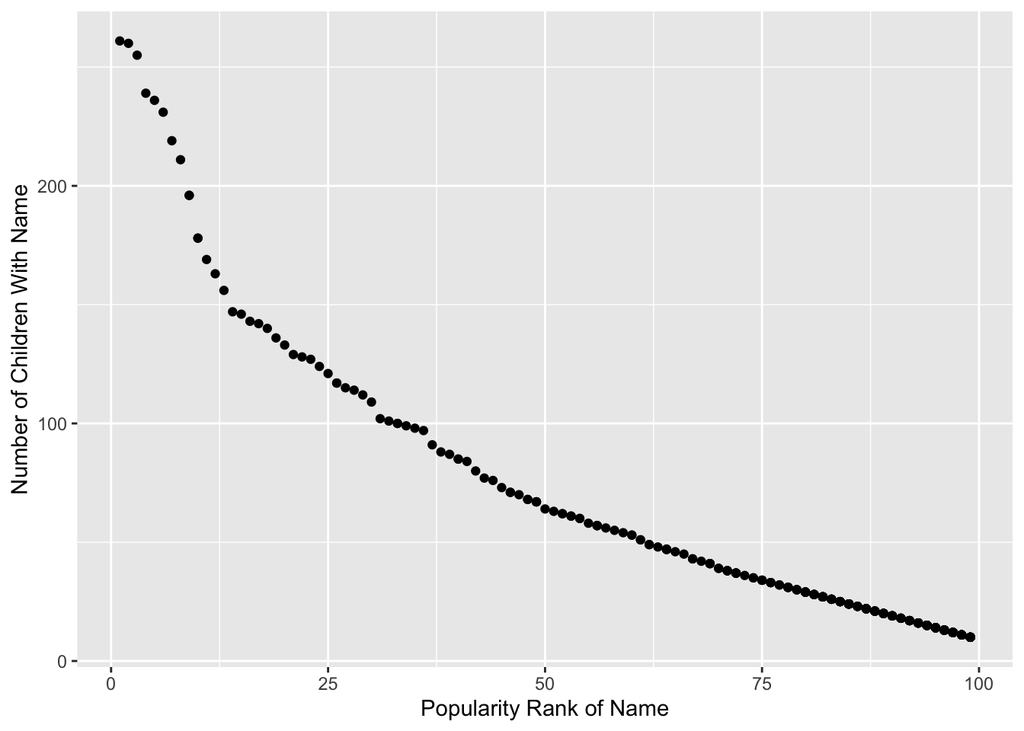

```r
boys_subset_df = babyname_df %>%
  filter(gender == "male", ethnicity == "white non hispanic", year_of_birth == "2016")
ggplot(boys_subset_df, aes(x = rank, y = count)) + geom_point() + ylab("Number of Children With Name") + xlab("Popularity Rank of Name")
```